# FocusGroup Package: Comprehensive Demonstration

AI-Powered Focus Group Simulation and Analysis with Rich ANES Data

FocusGroup Package Demo

2025-11-06

## Setup and Configuration

```r
# Load required packages
library(LLMR)
library(FocusGroup)
library(dplyr)
```

```r
library(ggplot2)
library(knitr)
if (requireNamespace("DT", quietly = TRUE)) library(DT)

# utilities used in this QMD
`%||%` <- function(x, y) if (is.null(x) || length(x) == 0) y else x

# NRC lexicon: attempt quiet, non-interactive setup; skip if unavailable
# Note: We intentionally avoid auto-downloading external lexicons to keep the demo clean and offline-friendly.

set.seed(1234)

# Configure LLM
llm_config <- LLMR::llm_config(
  provider = 'deepseek',
  model = 'deepseek-chat'
)

# Set focus group topic - Updated for 2025 political landscape
topic <- "Democratic Party strategies to win back Congress in 2026: addressing current voter concerns and emerging issues"
```

## Part 1: Rich Persona Development from ANES 2024 Data

### Creating Diverse Participants with 20+ Variables

We’ll demonstrate how the package creates extremely rich personas from actual survey data, leveraging the ANES (American National Election Studies) 2024 dataset with 20+ demographic and survey variables.

```r
# Source our ANES helpers
source("anes_2024/anes_helpers.R")

# Path to ANES data
anes_path <- "anes_2024/anes_timeseries_2024_stata.dta"

# Create 4 diverse participants using rich ANES data
print("Creating diverse participants from ANES 2024 survey data with 20+ variables...")
```

```
## [1] "Creating diverse participants from ANES 2024 survey data with 20+ variables..."
```

```r
agents <- create_agents_from_anes(
  n_participants = 4,
  anes_dta_path = anes_path,
  llm_config = llm_config
)

# Display participant personas
print("\n=== PARTICIPANT PERSONAS ===")
```

```
## [1] "\n=== PARTICIPANT PERSONAS ==="
```

```r
for (i in 1:(length(agents)-1)) {  # Exclude moderator
  agent <- agents[[i]]
  cat("\n**Participant", i, ":", agent$id, "**\n")
  # Demographics / survey are now properly structured as lists
  demostr <- if (length(agent$demographics) > 0) {
    paste(names(agent$demographics), unlist(agent$demographics), sep = ": ", collapse = "; ")
  } else {
    "Not specified"
  }
  survstr <- if (length(agent$survey_responses) > 0) {
    paste(names(agent$survey_responses), unlist(agent$survey_responses), sep = ": ", collapse = "; ")
  } else {
    "Not specified"
  }
  cat("Demographics (", length(agent$demographics), " variables):", substr(demostr, 1, 150), "...\n")
  cat("Survey Profile (", length(agent$survey_responses), " variables):", substr(survstr, 1, 150), "...\n")
  cat("Generated Persona:", substr(agent$persona_description, 1, 300), "...\n")
  cat(paste(rep("-", 80), collapse = ""), "\n")
}
```

```
##
## **Participant 1 : P1 **
## Demographics ( 16  variables): gender: Woman; education: Associate degree in college - Occupational/vocational program; race: No; marital_status: Heterosexual or straight; income: Y ...
## Survey Profile ( 15  variables): party_id: Not very strong Republican; vote_intent: Would not vote; approval_dem: Disapprove; approval_rep: Strongly; ideology: Republican; congress_ap ...
## Generated Persona: You are a unspecified-year-old woman with associate degree in college - occupational/vocational program education. You identify as a Republican and generally support Republican policies and conservative values. You generally approve of how Congress is handling its job and trust…
## --------------------------------------------------------------------------------
##
## **Participant 2 : P2 **
## Demographics ( 16  variables): gender: Woman; education: Bachelor's degree (For example: BA, AB, BS); race: No; marital_status: Heterosexual or straight; income: Yes; religion: REST ...
## Survey Profile ( 15  variables): party_id: Strong Democrat; vote_intent: Kamala Harris; approval_dem: Approve; approval_rep: Not strongly; ideology: Democrat; congress_approval: Disap ...
## Generated Persona: You are a unspecified-year-old woman with bachelor's degree education. You identify as a Democrat and generally support Democratic policies and progressive values. You plan to vote for Harris in the upcoming election and believe she represents the best choice for the country. Y…
## --------------------------------------------------------------------------------
##
## **Participant 3 : P3 **
## Demographics ( 16  variables): gender: Woman; education: Bachelor's degree (For example: BA, AB, BS); race: No; marital_status: Heterosexual or straight; income: No; religion: RESTR ...
## Survey Profile ( 15  variables): party_id: Independent-Democrat; vote_intent: Would not vote; approval_dem: Disapprove; approval_rep: Not strongly; ideology: Independent; congress_app ...
## Generated Persona: You are a unspecified-year-old woman with bachelor's degree education. You identify as a Democrat and generally support Democratic policies and progressive values. You generally approve of how Congress is handling its job and trust the legislative process. You approve of how th…
## --------------------------------------------------------------------------------
##
## **Participant 4 : P4 **
## Demographics ( 16  variables): gender: Woman; education: Some college but no degree; race: No; marital_status: Heterosexual or straight; income: No; religion: RESTRICTED; region: RE ...
## Survey Profile ( 16  variables): party_id: Independent; vote_intent: Would not vote; approval_dem: Approve; approval_rep: Not strongly; ideology: Independent; congress_approval: Disap ...
## Generated Persona: You are a unspecified-year-old woman with some college but no degree education. You identify as politically independent and evaluate issues on their merits rather than party lines. You generally approve of how Congress is handling its job and trust the legislative process. You …
## --------------------------------------------------------------------------------
```

```r
# Show moderator
moderator <- agents[[length(agents)]]
cat("\n**Moderator:", moderator$id, "**\n")
```

```
##
## **Moderator: MOD **
```

```r
cat("Role:", moderator$role, "\n")
```

```
## Role: moderator
```

```r
cat("Persona:", substr(moderator$persona_description, 1, 300), "...\n")
```

```
## Persona: You are an experienced focus group moderator. You facilitate discussion, ask follow-up questions, ensure all participants have opportunities to speak, and guide the conversation through different phases. You remain neutral and encouraging. ...
```

### Analyzing Persona Diversity

```r
# Extract demographic information for analysis
participants <- agents[1:(length(agents)-1)]

# Safe extraction with error handling - now that data is properly structured
safe_extract <- function(agent, field) {
  tryCatch({
    if (field == "demographics") {
      if (length(agent$demographics) > 0) {
        # Format key demographics nicely
        key_vars <- c("gender", "education", "race", "marital_status", "income")
        available_key <- key_vars[key_vars %in% names(agent$demographics)]
        if (length(available_key) > 0) {
          key_data <- paste(available_key, agent$demographics[available_key], sep = ": ", collapse = "; ")
          paste0(key_data, " (", length(agent$demographics), " total variables)")
        } else {
          paste0("Rich demographic profile (", length(agent$demographics), " variables)")
        }
      } else {
        "Not specified"
      }
    } else if (field == "survey_responses") {
      if (length(agent$survey_responses) > 0) {
        # Format key survey responses nicely
        key_vars <- c("party_id", "ideology", "vote_intent", "congress_approval")
        available_key <- key_vars[key_vars %in% names(agent$survey_responses)]
        if (length(available_key) > 0) {
          key_data <- paste(available_key, agent$survey_responses[available_key], sep = ": ", collapse = "; ")
          paste0(key_data, " (", length(agent$survey_responses), " total variables)")
        } else {
          paste0("Rich survey profile (", length(agent$survey_responses), " variables)")
        }
      } else {
        "Not specified"
      }
    } else {
      "Not available"
    }
  }, error = function(e) "Error extracting data")
}

# Create analysis dataframe
persona_data <- data.frame(
  id = sapply(participants, function(x) x$id),
  demographics = sapply(participants, function(x) safe_extract(x, "demographics")),
  survey_profile = sapply(participants, function(x) safe_extract(x, "survey_responses")),
  stringsAsFactors = FALSE
)

# Display persona diversity
DT::datatable(persona_data,
              caption = "Participant Demographics and Survey Profiles",
              options = list(pageLength = 4, dom = 't'))
```

|  | id | demographics | survey_profile |
| --- | --- | --- | --- |
| 1 | P1 | gender: Woman; education: Associate degree in college - Occupational/vocational program; race: No; marital_status: Heterosexual or straight; income: Yes (16 total variables) | party_id: Not very strong Republican; ideology: Republican; vote_intent: Would not vote; congress_approval: Disapprove (15 total variables) |
| 2 | P2 | gender: Woman; education: Bachelor's degree (For example: BA, AB, BS); race: No; marital_status: Heterosexual or straight; income: Yes (16 total variables) | party_id: Strong Democrat; ideology: Democrat; vote_intent: Kamala Harris; congress_approval: Disapprove (15 total variables) |
| 3 | P3 | gender: Woman; education: Bachelor's degree (For example: BA, AB, BS); race: No; marital_status: Heterosexual or straight; income: No (16 total variables) | party_id: Independent-Democrat; ideology: Independent; vote_intent: Would not vote; congress_approval: Disapprove (15 total variables) |
| 4 | P4 | gender: Woman; education: Some college but no degree; race: No; marital_status: Heterosexual or straight; income: No (16 total variables) | party_id: Independent; ideology: Independent; vote_intent: Would not vote; congress_approval: Disapprove (16 total variables) |

## Part 2: Focus Group Simulation

### Setting Up the Focus Group

```r
# Create focus group with our agents and improved conversation flow
moderator_id <- agents[[length(agents)]]$id
agents_named <- setNames(agents, sapply(agents, function(a) a$id))

# Use desire-based flow with lower threshold for more natural conversation
flow <- create_conversation_flow("desire_based", agents_named, moderator_id,
                                flow_params = list(min_desire_threshold = 2))

fg <- FocusGroup$new(
  topic = topic,
  purpose = "Explore diverse perspectives on Democratic Party strategies to win back Congress in the 2026 midterm elections, considering current voter concerns, economic challenges, and emerging political issues in 2025",
  agents = agents_named,
  moderator_id = moderator_id,
  turn_taking_flow = flow,
  llm_config_admin = llm_config
)
```

```
## No question_script provided. Using a minimal default script (opening, generic discussion, closing).
```

```r
# Define structured discussion phases with updated, relevant questions for 2025
question_script <- list(
  list(phase = "opening"),
  list(phase = "engagement_question", text = "Let's start with your overall impressions. As we look toward the 2026 midterms, what's your sense of the current political climate and where Americans are focused right now?"),
  list(phase = "exploration_question", text = "Thinking about key issues, what do you see as the most pressing concerns for voters going into 2026? Which of these should Democrats prioritize to connect with people?"),
  list(phase = "exploration_question", text = "Let's talk about messaging and communication. How should Democrats talk about the economy, given current inflation concerns and cost of living issues? What's working and what isn't?"),
  list(phase = "exploration_question", text = "What about coalition building? How should Democrats approach different voter groups - suburban voters, young voters, working-class voters - to rebuild their congressional majority?"),
  list(phase = "ending_question", text = "Finally, if you were advising the Democratic Party leadership, what would be your top recommendation for winning back Congress? What should they start doing now?"),
  list(phase = "closing")
)

# Set the question script
fg$question_script <- question_script

print("Focus group configured with structured discussion phases")
```

```
## [1] "Focus group configured with structured discussion phases"
```

### Running the Complete Simulation

```r
# Run the full simulation with increased turns (offline fallback if provider unavailable)
print("Running complete focus group simulation...")
```

```
## [1] "Running complete focus group simulation..."
```

```r
tryCatch({
  result <- fg$run_simulation(
    num_turns = 80,
    verbose = TRUE
  )
}, error = function(e) {
  message("LLM call failed: ", conditionMessage(e), " — using offline stub so the demo renders.")
  now <- Sys.time()
  fg$conversation_log <- list(
    list(turn = 1, speaker_id = moderator_id, is_moderator = TRUE, text = "Welcome everyone. Let's begin by sharing your overall impressions.", phase = "opening", timestamp = now),
    list(turn = 2, speaker_id = names(agents_named)[1], is_moderator = FALSE, text = "Voters care about economic stability and costs.", phase = "engagement_question", timestamp = now),
    list(turn = 3, speaker_id = names(agents_named)[2], is_moderator = FALSE, text = "Messaging needs clarity and credibility.", phase = "exploration_question", timestamp = now)
  )
})
```

```
## Starting focus group simulation...
## Topic: Democratic Party strategies to win back Congress in 2026: addressing current voter concerns and emerging issues
## Purpose: Explore diverse perspectives on Democratic Party strategies to win back Congress in the 2026 midterm elections, considering current voter concerns, economic challenges, and emerging political issues in 2025
##
## --- Turn 1 | Phase: opening ---
## MOD (Moderator): Of course. Here are the opening remarks for the focus group.
##
## ***
##
## **(The moderator smiles and makes eye contact with the participants.)**
##
## Good morning, everyone, and a very warm welcome. Thank you so much for taking the time to join us today. Your perspectives are incredibly valuable.
##
## My role here is to serve as your moderator. I’ll be facilitating our discussion, ensuring we hear from everyone, and guiding us through the various phases of our conversation. My job is to remain neutral and help create a comfortable and productive environment for all of you.
##
## The main topic we are here to discuss is: **'Democratic Party strategies to win back Congress in 2026: addressing current voter concerns and emerging issues.'**
##
## The specific purpose of this focus group is to **explore diverse perspectives on Democratic Party strategies to win back Congress in the 2026 midterm elections, considering current voter concerns, economic challenges, and emerging political issues in 2025.**
##
## To make sure our time together is as effective and respectful as possible, I’d like to establish a few simple ground rules:
##
## *   First, please let’s have one person speak at a time so we can all hear each other clearly.
## *   All opinions are valuable. There are no right or wrong answers here.
## *   It is perfectly safe to disagree, and we encourage a respectful exchange of ideas. Please remember to critique ideas, not the people presenting them.
## *   Let's avoid interruptions and personal attacks.
## *
##
## --- Turn 2 | Phase: engagement_question | Current Question/Focus: Let's start with your overall impressions. As we look toward the 2026 midterms, what's your sense of... ---
## MOD (Moderator): **(The moderator leans forward slightly, projecting an open and engaged demeanor. Their gaze sweeps the group to include everyone.)**
##
## "Excellent. Thank you for that introduction. Now, let's begin our discussion in earnest."
##
## "The first question I'd like to pose to the group is a broad one to get us started. Let's start with your overall impressions. As we look toward the 2026 midterms, what's your sense of the current political climate and where Americans are focused right now?"
##
## **(The moderator pauses, allowing the question to settle. They place their pen down, signaling they are listening, not just waiting to talk.)**
##
## "P1, P2, P3, P4... please, just jump in. There's no particular order. I'm interested in your individual sense of the national mood."
```

```
## Selected participant by flow: P4
## P4: It feels like everyone is just exhausted by the constant arguing. From what I hear at work and with my friends, people are really focused on the basics—things like the cost of groceries and their monthly rent. It’s hard to think about big political strategies when you’re worried about making …
## Selected participant by flow: P2
## P2: I agree with P4 about the exhaustion. It feels like the political noise is a constant distraction from the real progress being made. But from my own experience, with my financial situation stabilizing, I'm starting to feel more optimistic. I think a lot of people are focused on that—on whethe…
## Selected participant by flow: P1
## P1: I agree that people are tired of the fighting, but I see it a bit differently. From my own experience, things have gotten better for my family financially, and that makes me more confident in the direction we're headed. I think a lot of people are looking for competence and a government that …
## Maximum participant exchanges reached for this round.
##
## --- Turn 3 | Phase: exploration_question | Current Question/Focus: Thinking about key issues, what do you see as the most pressing concerns for voters going into 2026?... ---
## MOD (Moderator): **(The moderator nods thoughtfully, acknowledging the points made by P4, P2, and P1.)**
##
## "Thank you, all three of you. That's a very helpful starting point. You've all touched on this sense of exhaustion with political conflict and a desire for stability, with a particular emphasis on economic security as a foundational concern."
##
## **(The moderator shifts their posture slightly, inviting a deeper level of analysis from the entire group.)**
##
## "Let's build on that and drill down a bit further. I'd like to pose our next key question to everyone."
##
## **"Thinking about key issues, what do you see as the most pressing concerns for voters going into 2026? And, perhaps more strategically, which of these should Democrats prioritize to connect with people?"**
##
## **(The moderator gestures openly, encouraging a free-flowing exchange.)**
##
## "P3, we haven't heard from you yet on this, and I'm very interested in your perspective. And for everyone, feel free to build on what others have said or introduce a new angle. Is it all economic, or are there other issues—like healthcare, climate, or social issues—that you see as equally pressin…
## Selected participant by flow: P4
## P4: I definitely hear what P4 and the others are saying about the economy. That's a huge piece of it. But from my own view, I think the issues of personal freedom are just as urgent right now. I'm talking about a woman's right to choose and the need for common-sense gun safety laws. When I see th…
## Selected participant by flow: P3
## P3: I completely agree with P4 that protecting our fundamental freedoms is a top concern. For me, seeing the attacks on abortion access has been the most galvanizing issue. It’s not an abstract debate; it’s about real healthcare and autonomy. Democrats need to prioritize this and make it clear th…
## Selected participant by flow: P2
## P2: I think P4 and P3 are absolutely right about personal freedoms being a core concern. For me, the economic stability we're discussing feels fragile if we're losing ground on other fundamental rights. Beyond reproductive care and gun safety, I'm increasingly worried about threats to democracy i…
## Maximum participant exchanges reached for this round.
##
## --- Turn 4 | Phase: exploration_question | Current Question/Focus: Let's talk about messaging and communication. How should Democrats talk about the economy, given cur... ---
## MOD (Moderator): **(The moderator leans forward, making eye contact with the group as they synthesize the previous comments.)**
##
## "Excellent. Thank you, P4, P3, and P2. You've all made a powerful and crucial connection between economic stability and personal freedoms, arguing that they are inseparable for many voters. This idea of a foundational security that includes both financial well-being and individual rights is a ver…
##
## **(The moderator smoothly pivots the group toward the core task of the discussion.)**
##
## "Now, I'd like us to take that concept and apply it directly to one of the most challenging areas for any political party: economic messaging. Let's talk about messaging and communication."
##
## **"How should Democrats talk about the economy, given current inflation concerns and cost of living issues? What's working and what isn't?"**
```

[output cut: 72 more lines]

```
##
## Our team will now carefully review the full transcript from our discussion. Your insights will become part of a larger analysis to help inform the path forward.
##
## Thank you again for your candor and for making this such a productive conversation. You are free to log off, and have a wonderful rest of your day.
## Moderator initiated closing. Ending simulation.
##
## --- Generating final summary of the entire discussion ---
## Final Summary:
##  Based on the focus group discussion, participants expressed a broad consensus that voters are exhausted by political conflict and primarily concerned with economic stability and personal freedoms, viewing the two as deeply interconnected. The overall sentiment was that Democrats must craft a mor…
##
## A key agreement emerged on economic messaging: simply citing positive macroeconomic statistics like job growth is ineffective and feels out of touch. Participants recommended that Democrats instead acknowledge the ongoing pain of high costs while highlighting concrete, specific plans to lower exp…
##
## There was strong alignment on the critical importance of protecting personal freedoms, particularly abortion access, which was described as a galvanizing issue that is fundamental to both autonomy and economic security. This led to the core strategic recommendation: the party must stop treating i…
##
## Regarding coalition building, participants advised against taking any voter group for granted. They suggested tailoring the message to different demographics—for example, emphasizing freedoms and fiscal responsibility for suburban voters, and long-term plans on climate and student debt for young …
```

```r
print("Simulation step completed (live or offline).")
```

```
## [1] "Simulation step completed (live or offline)."
```

```r
print(paste("Total conversation turns:", length(fg$conversation_log)))
```

```
## [1] "Total conversation turns: 24"
```

```r
print(paste("Participants involved:", length(unique(sapply(fg$conversation_log, function(x) x$speaker_id)))))
```

```
## [1] "Participants involved: 6"
```

### Complete Focus Group Transcript

```r
# Display the complete transcript with collapsible sections
cat("## Complete Focus Group Transcript\n\n")
```

## Complete Focus Group Transcript

```r
# Verify we have conversation data
if (length(fg$conversation_log) > 0) {
  cat("### Participants and Overview\n\n")

  # Extract speaker information
  all_speakers <- unique(sapply(fg$conversation_log, function(x) x$speaker_id))
  moderator_turns <- sum(sapply(fg$conversation_log, function(x) x$speaker_id == moderator_id))
  participant_turns <- length(fg$conversation_log) - moderator_turns

  cat("- **Total turns:** ", length(fg$conversation_log), "\n")
  cat("- **Moderator turns:** ", moderator_turns, "\n")
  cat("- **Participant turns:** ", participant_turns, "\n")
  cat("- **Active speakers:** ", paste(all_speakers, collapse = ", "), "\n\n")

  cat("### Full Conversation (", length(fg$conversation_log), " exchanges)\n\n")

  # Create collapsible HTML sections for each turn
  for (i in 1:length(fg$conversation_log)) {
    entry <- fg$conversation_log[[i]]

    # Extract data safely
    speaker <- entry$speaker_id %||% "Unknown Speaker"
    text <- entry$text %||% "No content"
    timestamp <- entry$timestamp %||% Sys.time()
    phase <- entry$phase %||% "unknown"
    turn_num <- entry$turn %||% i

    # Determine speaker type for styling
    speaker_type <- ifelse(speaker == moderator_id, "Moderator", "Participant")
    border_color <- ifelse(speaker == moderator_id, "#28a745", "#007bff")

    # Create collapsible HTML with improved styling
    cat('<details>\n')
    cat('<summary><strong>Turn ', i, ' - ', speaker, '</strong> (',
        speaker_type, ' • ',
        format(as.POSIXct(timestamp), "%H:%M:%S"), ' • ',
        tools::toTitleCase(phase), ')</summary>\n')
    cat('<div style="margin-left: 20px; padding: 15px; margin-top: 10px; background-color: #f8f9fa; border-left: 4px solid ', border_color, '; border-radius: 5px;">\n')
    cat('<p style="margin: 0; line-height: 1.5;">', gsub("\n", "<br/>", text), '</p>\n')
    cat('</div>\n')
    cat('</details>\n\n')
  }

  # Also provide a condensed view for quick scanning
  cat("\n---\n\n### Condensed View (First 15 exchanges)\n\n")
  for (i in 1:min(15, length(fg$conversation_log))) {
    entry <- fg$conversation_log[[i]]
    speaker <- entry$speaker_id %||% "Unknown"
    text <- entry$text %||% "No content"

    # Truncate long responses
    display_text <- if(nchar(text) > 120) {
      paste0(substr(text, 1, 120), "...")
    } else {
      text
    }

    cat("**", speaker, ":** ", display_text, "\n\n")
  }

  if (length(fg$conversation_log) > 15) {
    cat("*... and ", length(fg$conversation_log) - 15, " more exchanges. See full transcript above.*\n\n")
  }

} else {
  cat("*No conversation data available. The simulation may not have run properly.*\n\n")
  cat("Debug info:\n")
  cat("- fg object exists: ", !is.null(fg), "\n")
  cat("- conversation_log exists: ", !is.null(fg$conversation_log), "\n")
  cat("- conversation_log length: ", length(fg$conversation_log %||% list()), "\n")
}
```

### Participants and Overview

- **Total turns:** 24
- **Moderator turns:** 7
- **Participant turns:** 17
- **Active speakers:** System, MOD, P4, P2, P1, P3

### Full Conversation ( 24 exchanges)

**Turn 1 - System** ( Participant • 13:41:27 • Setup )**

Participants: P1, P2, P3, P4; Moderator: MOD

**Turn 2 - MOD** ( Moderator • 13:41:41 • Opening )**

Of course. Here are the opening remarks for the focus group.  
*  
(The moderator smiles and makes eye contact with the participants.)  
Good morning, everyone, and a very warm welcome. Thank you so much for taking the time to join us today. Your perspectives are incredibly valuable.  
My role here is to serve as your moderator. I’ll be facilitating our discussion, ensuring we hear from everyone, and guiding us through the various phases of our conversation. My job is to remain neutral and help create a comfortable and productive environment for all of you.  
The main topic we are here to discuss is: ’Democratic Party strategies to win back Congress in 2026: addressing current voter concerns and emerging issues.’  
**The specific purpose of this focus group is to** explore diverse perspectives on Democratic Party strategies to win back Congress in the 2026 midterm elections, considering current voter concerns, economic challenges, and emerging political issues in 2025.**  
To make sure our time together is as effective and respectful as possible, I’d like to establish a few simple ground rules:  
* First, please let’s have one person speak at a time so we can all hear each other clearly.  
* All opinions are valuable. There are no right or wrong answers here.  
* It is perfectly safe to disagree, and we encourage a respectful exchange of ideas. Please remember to critique ideas, not the people presenting them.  
* Let’s avoid interruptions and personal attacks.  
*

**Turn 3 - MOD** ( Moderator • 13:41:51 • Engagement_question )**

**(The moderator leans forward slightly, projecting an open and engaged demeanor. Their gaze sweeps the group to include everyone.)**  
“Excellent. Thank you for that introduction. Now, let’s begin our discussion in earnest.”  
“The first question I’d like to pose to the group is a broad one to get us started. Let’s start with your overall impressions. As we look toward the 2026 midterms, what’s your sense of the current political climate and where Americans are focused right now?”  
**(The moderator pauses, allowing the question to settle. They place their pen down, signaling they are listening, not just waiting to talk.)**  
“P1, P2, P3, P4… please, just jump in. There’s no particular order. I’m interested in your individual sense of the national mood.”

**Turn 4 - P4** ( Participant • 13:42:00 • Engagement_question )**

It feels like everyone is just exhausted by the constant arguing. From what I hear at work and with my friends, people are really focused on the basics—things like the cost of groceries and their monthly rent. It’s hard to think about big political strategies when you’re worried about making ends meet.

**Turn 5 - P2** ( Participant • 13:42:11 • Engagement_question )**

I agree with P4 about the exhaustion. It feels like the political noise is a constant distraction from the real progress being made. But from my own experience, with my financial situation stabilizing, I’m starting to feel more optimistic. I think a lot of people are focused on that—on whether they feel secure and if the country is on a stable path. The Democrats need to cut through the chaos and really highlight that stability and economic recovery.

**Turn 6 - P1** ( Participant • 13:42:19 • Engagement_question )**

I agree that people are tired of the fighting, but I see it a bit differently. From my own experience, things have gotten better for my family financially, and that makes me more confident in the direction we’re headed. I think a lot of people are looking for competence and a government that just functions without the constant drama.

**Turn 7 - MOD** ( Moderator • 13:42:33 • Exploration_question )**

**(The moderator nods thoughtfully, acknowledging the points made by P4, P2, and P1.)**  
“Thank you, all three of you. That’s a very helpful starting point. You’ve all touched on this sense of exhaustion with political conflict and a desire for stability, with a particular emphasis on economic security as a foundational concern.”  
**(The moderator shifts their posture slightly, inviting a deeper level of analysis from the entire group.)**  
“Let’s build on that and drill down a bit further. I’d like to pose our next key question to everyone.”  
**“Thinking about key issues, what do you see as the most pressing concerns for voters going into 2026? And, perhaps more strategically, which of these should Democrats prioritize to connect with people?”**  
**(The moderator gestures openly, encouraging a free-flowing exchange.)**  
“P3, we haven’t heard from you yet on this, and I’m very interested in your perspective. And for everyone, feel free to build on what others have said or introduce a new angle. Is it all economic, or are there other issues—like healthcare, climate, or social issues—that you see as equally pressing for voters?”

**Turn 8 - P4** ( Participant • 13:42:44 • Exploration_question )**

I definitely hear what P4 and the others are saying about the economy. That’s a huge piece of it. But from my own view, I think the issues of personal freedom are just as urgent right now. I’m talking about a woman’s right to choose and the need for common-sense gun safety laws. When I see those rights being chipped away, it doesn’t feel like the stability P1 mentioned is possible. For Democrats to connect with people like me, they need to show they are the ones actively protecting those freedoms, not just talking about them.

**Turn 9 - P3** ( Participant • 13:42:53 • Exploration_question )**

I completely agree with P4 that protecting our fundamental freedoms is a top concern. For me, seeing the attacks on abortion access has been the most galvanizing issue. It’s not an abstract debate; it’s about real healthcare and autonomy. Democrats need to prioritize this and make it clear they are the last line of defense, because when those rights are gone, the economic stability we’re talking about feels meaningless.

**Turn 10 - P2** ( Participant • 13:43:06 • Exploration_question )**

I think P4 and P3 are absolutely right about personal freedoms being a core concern. For me, the economic stability we’re discussing feels fragile if we’re losing ground on other fundamental rights. Beyond reproductive care and gun safety, I’m increasingly worried about threats to democracy itself—voting rights, fair elections—which underpins everything else. Democrats should prioritize this interconnected message: that economic security and personal freedom are two sides of the same coin, and you can’t have one without the other.

**Turn 11 - MOD** ( Moderator • 13:43:23 • Exploration_question )**

**(The moderator leans forward, making eye contact with the group as they synthesize the previous comments.)**  
“Excellent. Thank you, P4, P3, and P2. You’ve all made a powerful and crucial connection between economic stability and personal freedoms, arguing that they are inseparable for many voters. This idea of a foundational security that includes both financial well-being and individual rights is a very compelling thread.”  
**(The moderator smoothly pivots the group toward the core task of the discussion.)**  
“Now, I’d like us to take that concept and apply it directly to one of the most challenging areas for any political party: economic messaging. Let’s talk about messaging and communication.”  
**“How should Democrats talk about the economy, given current inflation concerns and cost of living issues? What’s working and what isn’t?”**  
**(The moderator gestures to the group, inviting a practical and critical discussion.)**  
“For instance, when you hear a politician say ‘the economy is strong,’ does that resonate if your grocery bill is still high? Is the focus on job numbers effective, or does it feel disconnected from daily struggles? How can they acknowledge the very real pain P4 mentioned, while also highlighting the progress and stability that P1 and P2 are feeling? P1, since you mentioned your family’s improving financial situation, what kind of economic message would feel authentic to you? And P4, from your perspective of worry about making ends meet, what would a convincing message sound like?”  
**(The moderator opens the floor, encouraging a free-flowing exchange.)**  
“Let’s brainstorm this. What’s the right tone, the right focus? Feel free to build on each other’s ideas.”

**Turn 12 - P4** ( Participant • 13:43:34 • Exploration_question )**

I think they need to stop just reciting statistics about job growth and start talking about real prices. When I hear “the economy is strong,” but I’m still paying so much more for groceries and utilities, it feels out of touch. They should acknowledge the strain people are under, then talk about specific, concrete plans to lower costs, like on prescription drugs or childcare. That would feel more honest and helpful.

**Turn 13 - P3** ( Participant • 13:43:44 • Exploration_question )**

I agree with P4 about the need to move past just citing job numbers. For me, the message that resonates is about building on the progress we’ve made. My own financial situation has improved, and I want to hear how Democrats plan to make that stability more widespread. They should talk about protecting the gains we have—like preventing cuts to Social Security or Medicare—while being honest that there’s more work to do on lowering everyday costs. It’s about securing the foundation, not declaring mission accomplished.

**Turn 14 - P4** ( Participant • 13:43:56 • Exploration_question )**

I agree that just saying “the economy is strong” rings hollow when you’re staring at a high grocery receipt. But I also think P3 has a point about not dismissing the progress entirely. For me, a message that acknowledges the real cost-of-living pain while focusing on practical, bipartisan solutions would work best. Talk about lowering specific costs, like making the child tax credit permanent or cracking down on junk fees, not just reciting top-line numbers. That feels honest and actionable.

**Turn 15 - MOD** ( Moderator • 13:44:13 • Exploration_question )**

**(The moderator nods thoughtfully, acknowledging the points made about economic messaging.)**  
“That’s a very productive discussion on economic messaging. The need for honesty about costs, a focus on concrete solutions, and acknowledging progress without declaring ‘mission accomplished’—these are all crucial ingredients. It seems the consensus is that the message must be both empathetic and practical.”  
**(The moderator smoothly transitions, gesturing to encompass the whole group.)**  
“Now, let’s build on that. A compelling message is only effective if it reaches the right people in the right way. This brings us to the critical task of coalition building. The Democratic coalition is broad, and winning a congressional majority means speaking to its different parts effectively.”  
**“What about coalition building? How should Democrats approach different voter groups—suburban voters, young voters, working-class voters—to rebuild their congressional majority?”**  
**(The moderator leans back slightly, opening the floor for a broader exchange.)**  
“Think about the themes we’ve discussed: economic stability, personal freedoms, and the need for authentic communication. How do those translate when talking to a suburban parent concerned about schools and property taxes versus a young voter focused on student debt and climate action versus a working-class voter prioritizing good jobs and affordable healthcare?”  
“P2, you mentioned the interconnectedness of issues. How does that philosophy apply to building a coalition? P4, from your perspective on cost-of-living, what would a persuasive pitch to a working-class voter look like? And P3, considering your focus on protecting freedoms, how does that appeal to suburban voters?”  
“Let’s hear from everyone. How can the party speak to these groups without a one-size-fits-all approach? Feel free to jump in and build on each other’s thoughts.”

**Turn 16 - P1** ( Participant • 13:44:24 • Exploration_question )**

I think they need to be careful not to take any group for granted. For suburban voters like me, the focus on personal freedoms really resonates—things like protecting abortion access and making sure our kids are safe with common-sense gun measures. But they can’t ignore that we also care about fiscal responsibility and keeping our taxes manageable. It’s about showing they understand the whole picture, not just one or two issues.

**Turn 17 - P4** ( Participant • 13:44:35 • Exploration_question )**

I agree with P1 about not taking voters for granted. For young voters, it’s not enough to just promise student debt relief. They need to see a clear, long-term plan for making college and healthcare affordable and tangible action on climate. It feels like they get a lot of promises during elections, but follow-through is what builds real trust.

**Turn 18 - P2** ( Participant • 13:44:45 • Exploration_question )**

I think P1 and P4 are both right about not taking groups for granted. For working-class voters, I’d add that Democrats need to connect the dots between protecting freedoms and economic stability. When we talk about abortion rights, it’s not just a social issue—it’s about being able to make decisions about your family and career without government interference. That’s economic security too. And on immigration, we should emphasize how providing opportunities for immigrants strengthens our communities and economy, which benefits everyone.

**Turn 19 - MOD** ( Moderator • 13:44:58 • Ending_question )**

**(The moderator leans forward, making eye contact with each participant in turn.)**  
“Excellent points. The need to avoid taking any voter bloc for granted, to connect abstract freedoms to tangible economic security, and to prioritize clear, long-term plans over just campaign promises… this is all incredibly valuable.”  
**(The moderator checks the time and adopts a slightly more conclusive tone.)**  
“We’re just about out of time, and you’ve all provided such thoughtful, concrete insights on messaging and coalition building. I’d like to end with one final, overarching question to synthesize your perspectives.”  
**“Finally, if you were advising the Democratic Party leadership, what would be your top recommendation for winning back Congress? What should they start doing *now*?”**  
**(The moderator gestures openly to the group.)**  
“Think of this as your key takeaway. Based on our entire conversation—from economic messaging to connecting with different voters—what is the single most important piece of advice you would give? P1, P2, P3, P4, let’s hear from each of you for a final thought.”

**Turn 20 - P3** ( Participant • 13:45:08 • Ending_question )**

My top recommendation would be to stop treating every issue as separate and start showing how they’re all connected to people’s daily lives. When we talk about protecting abortion rights, we should explicitly tie it to economic security and family stability. When we talk about climate action, we should highlight the job creation potential. People need to see the Democratic platform as one cohesive vision for making life better, not a checklist of disconnected policies.

**Turn 21 - P2** ( Participant • 13:45:18 • Ending_question )**

I completely agree with P3 about connecting the issues. My top advice would be to communicate their accomplishments more clearly and consistently. I feel more secure financially because of policies like the infrastructure bill and lower prescription drug costs, but many people don’t realize these are Democratic achievements. They need to tell that story everywhere—not just in campaign season—so voters understand how their lives are improving right now because of Democratic governance.

**Turn 22 - P3** ( Participant • 13:45:29 • Ending_question )**

I think P2 and P3 are both onto something crucial. My top recommendation would be to demonstrate consistent follow-through. I’ve felt more financially secure recently because of Democratic policies, but that message isn’t reaching everyone. They need to show voters—not just tell them—that they’re delivering on promises right now, whether it’s protecting reproductive rights or lowering costs. Trust comes from seeing real results in your daily life, not just hearing pledges during election season.

**Turn 23 - MOD** ( Moderator • 13:45:38 • Closing )**

Excellent. Well, that brings us to the end of our scheduled discussion.  
I want to start by sincerely thanking each and every one of you. Your time, your energy, and most importantly, your incredibly valuable contributions made this a truly insightful session. You’ve shared a wide range of perspectives, personal experiences, and thoughtful ideas, which is exactly what we hoped to explore.  
As a quick reminder, your input here is crucial. This conversation, with all its diverse viewpoints on everything from economic pressures to social issues, will be analyzed to better understand the landscape of voter concerns as the Democratic Party considers its strategies for the 2026 midterms.  
Please remember that, as I mentioned at the start, your comments will remain confidential and anonymous in any reporting from this session. We are interested in the collective themes and ideas, not in attributing specific comments to individuals.  
Our team will now carefully review the full transcript from our discussion. Your insights will become part of a larger analysis to help inform the path forward.  
Thank you again for your candor and for making this such a productive conversation. You are free to log off, and have a wonderful rest of your day.

**Turn 24 - System** ( Participant • 13:45:49 • Final_summary )**

Final Summary:  
Based on the focus group discussion, participants expressed a broad consensus that voters are exhausted by political conflict and primarily concerned with economic stability and personal freedoms, viewing the two as deeply interconnected. The overall sentiment was that Democrats must craft a more authentic and cohesive message that resonates with these dual priorities.  
A key agreement emerged on economic messaging: simply citing positive macroeconomic statistics like job growth is ineffective and feels out of touch. Participants recommended that Democrats instead acknowledge the ongoing pain of high costs while highlighting concrete, specific plans to lower expenses like groceries, childcare, and prescription drugs.  
There was strong alignment on the critical importance of protecting personal freedoms, particularly abortion access, which was described as a galvanizing issue that is fundamental to both autonomy and economic security. This led to the core strategic recommendation: the party must stop treating issues as separate and instead present a unified vision that explicitly links economic stability with the protection of individual rights.  
Regarding coalition building, participants advised against taking any voter group for granted. They suggested tailoring the message to different demographics—for example, emphasizing freedoms and fiscal responsibility for suburban voters, and long-term plans on climate and student debt for young voters—while consistently demonstrating follow-through on promises to build trust. The top recommendation for party leadership was to more clearly and consistently communicate their current accomplishments, making voters aware of how Democratic policies are already delivering tangible benefits in their daily lives.

### Condensed View (First 15 exchanges)

** System :** Participants: P1, P2, P3, P4; Moderator: MOD

** MOD :** Of course. Here are the opening remarks for the focus group.

**(The moderator smiles and makes eye contact with th…

** MOD :** **(The moderator leans forward slightly, projecting an open and engaged demeanor. Their gaze sweeps the group to include…

** P4 :** It feels like everyone is just exhausted by the constant arguing. From what I hear at work and with my friends, people a…

** P2 :** I agree with P4 about the exhaustion. It feels like the political noise is a constant distraction from the real progress…

** P1 :** I agree that people are tired of the fighting, but I see it a bit differently. From my own experience, things have gotte…

** MOD :** **(The moderator nods thoughtfully, acknowledging the points made by P4, P2, and P1.)**

“Thank you, all three of you. T…

** P4 :** I definitely hear what P4 and the others are saying about the economy. That’s a huge piece of it. But from my own view, …

** P3 :** I completely agree with P4 that protecting our fundamental freedoms is a top concern. For me, seeing the attacks on abor…

** P2 :** I think P4 and P3 are absolutely right about personal freedoms being a core concern. For me, the economic stability we’r…

** MOD :** **(The moderator leans forward, making eye contact with the group as they synthesize the previous comments.)**

“Excelle…

** P4 :** I think they need to stop just reciting statistics about job growth and start talking about real prices. When I hear “th…

** P3 :** I agree with P4 about the need to move past just citing job numbers. For me, the message that resonates is about buildin…

** P4 :** I agree that just saying “the economy is strong” rings hollow when you’re staring at a high grocery receipt. But I also …

** MOD :** **(The moderator nods thoughtfully, acknowledging the points made about economic messaging.)**

“That’s a very productiv…

*… and 9 more exchanges. See full transcript above.*

## Part 3: Comprehensive Analysis

Now we’ll apply ALL available analysis tools to extract insights from our focus group discussion.

### Basic Summary Statistics

```r
# Get comprehensive statistics using the quick analysis function
cat("### Basic Focus Group Statistics\n\n")
```

```
## ### Basic Focus Group Statistics
```

```r
basic_analysis <- fg_analyze_quick(fg)

if (!is.null(basic_analysis) && !is.null(basic_analysis$basic_stats)) {
  stats_df <- data.frame(
    Metric = names(basic_analysis$basic_stats),
    Value = unlist(basic_analysis$basic_stats),
    stringsAsFactors = FALSE
  )
  knitr::kable(stats_df, caption = "Focus Group Summary Statistics")
} else {
  cat("Basic statistics not available\n")
}
```

Focus Group Summary Statistics

|  | Metric | Value |
| --- | --- | --- |
| total_messages | total_messages | 24.0000 |
| participant_count | participant_count | 5.0000 |
| avg_message_length | avg_message_length | 750.0833 |
| total_tokens | total_tokens | 28388.0000 |

```r
# Additional manual statistics
cat("\n**Participation Breakdown:**\n\n")
```

```
##
## **Participation Breakdown:**
```

```r
if (length(fg$conversation_log) > 0) {
  speaker_counts <- table(sapply(fg$conversation_log, function(x) x$speaker_id))
  for (speaker in names(speaker_counts)) {
    cat("- ", speaker, ": ", speaker_counts[speaker], " contributions\n")
  }

  # Calculate speaking time distribution
  total_words <- sum(sapply(fg$conversation_log, function(x) length(strsplit(x$text, "\\s+")[[1]])))
  cat("\n- **Total words spoken:** ", total_words, "\n")
  cat("- **Average words per turn:** ", round(total_words / length(fg$conversation_log), 1), "\n")
}
```

```
## -  MOD :  7  contributions
## -  P1 :  2  contributions
## -  P2 :  4  contributions
## -  P3 :  4  contributions
## -  P4 :  5  contributions
## -  System :  2  contributions
##
## - **Total words spoken:**  2807
## - **Average words per turn:**  117
```

### Topic Modeling

```r
cat("### Topic Modeling Results\n\n")
```

```
## ### Topic Modeling Results
```

```r
topic_results <- fg$analyze_topics(n_topics = 4)  # Reduced for clearer themes
if (!is.null(topic_results)) {
  if (is.character(topic_results)) {
    cat(topic_results)
  } else if (is.list(topic_results)) {
    if (!is.null(topic_results$topics)) {
      cat("**Discovered Topics:**\n\n")
      for (i in 1:length(topic_results$topics)) {
        cat("**Topic", i, ":**", topic_results$topics[[i]], "\n\n")
      }
    }
    if (!is.null(topic_results$keywords)) {
      cat("**Key Terms:**\n")
      print(head(topic_results$keywords, 15))
    }
  }
} else {
  cat("Topic modeling results not available\n")
}
```

[output not shown]

### TF-IDF Analysis

```r
cat("### TF-IDF Analysis (Most Important Terms)\n\n")
```

```
## ### TF-IDF Analysis (Most Important Terms)
```

```r
tfidf_results <- fg$analyze_tfidf()
if (!is.null(tfidf_results) && nrow(tfidf_results) > 0) {
  # Show top terms overall
  top_terms <- head(tfidf_results %>% arrange(desc(tf_idf)), 15)
  print(knitr::kable(top_terms, caption = "Top 15 Terms by TF-IDF Score", digits = 4))

  # Show top terms by speaker
  if ("speaker_id" %in% names(tfidf_results)) {
    cat("\n**Top terms by speaker:**\n\n")
    for (speaker in unique(tfidf_results$speaker_id)) {
      speaker_terms <- tfidf_results %>%
        filter(speaker_id == speaker) %>%
        arrange(desc(tf_idf)) %>%
        head(5)

      if (nrow(speaker_terms) > 0) {
        cat("*", speaker, ":*", paste(speaker_terms$term, collapse = ", "), "\n\n")
      }
    }
  }
} else {
  cat("TF-IDF analysis results not available\n")
}
```

```
##
##
## Table: Top 15 Terms by TF-IDF Score
##
## |speaker_id |term         | tf_idf|
## |:----------|:------------|------:|
## |P1         |careful      | 0.0390|
## |P1         |competence   | 0.0390|
## |P1         |confident    | 0.0390|
## |P1         |direction    | 0.0390|
## |P1         |drama        | 0.0390|
## |P1         |fighting     | 0.0390|
## |P1         |functions    | 0.0390|
## |P1         |headed       | 0.0390|
## |P1         |ignore       | 0.0390|
## |P1         |keeping      | 0.0390|
## |MOD        |moderator    | 0.0305|
## |System     |participants | 0.0303|
## |P3         |life         | 0.0274|
## |P3         |it’s  | 0.0252|
## |P4         |reciting     | 0.0249|
##
## **Top terms by speaker:**
##
## * MOD :* moderator, free, time, 2026, concerns
##
## * P1 :* careful, competence, confident, direction, drama
##
## * P2 :* secure, feel, economic, absolutely, achievements
##
## * P3 :* life, it’s, lowering, checklist, connected
##
## * P4 :* reciting, cost, groceries, honest, it’s
##
## * System :* participants, consistently, party, advised, agreement
```

### Key Phrase Extraction

```r
cat("### Key Phrase Extraction\n\n")
```

```
## ### Key Phrase Extraction
```

```r
key_phrases <- fg$analyze_key_phrases()
if (!is.null(key_phrases)) {
  if (is.character(key_phrases)) {
    cat(key_phrases)
  } else if (is.list(key_phrases)) {
    if (!is.null(key_phrases$phrases)) {
      cat("**Extracted Key Phrases:**\n\n")
      for (i in 1:min(length(key_phrases$phrases), 10)) {
        cat("-", key_phrases$phrases[i], "\n")
      }
    }
  }
} else {
  cat("Key phrase extraction results not available\n")
}
```

[output not shown]

### Readability Analysis

```r
cat("### Readability Analysis\n\n")
```

```
## ### Readability Analysis
```

```r
# Try multiple readability measures
readability_measures <- c("Flesch", "Flesch.Kincaid", "ARI")
for (measure in readability_measures) {
  cat("#### ", measure, " Readability:\n\n")
  readability_results <- fg$analyze_readability(measures = measure)
  if (!is.null(readability_results) && nrow(readability_results) > 0) {
    print(knitr::kable(readability_results, caption = paste(measure, "Readability Scores"), digits = 2))
    cat("\n")
  } else {
    cat("No readability results available for", measure, "\n\n")
  }
}
```

```
## ####  Flesch  Readability:
```

```
##
##
## Table: Flesch Readability Scores
##
## |speaker_id |document | Flesch|
## |:----------|:--------|------:|
## |1          |MOD      |  52.18|
## |2          |P1       |  55.88|
## |3          |P2       |  42.21|
## |4          |P3       |  48.78|
## |5          |P4       |  65.59|
## |6          |System   |   7.12|
##
## ####  Flesch.Kincaid  Readability:
##
##
##
## Table: Flesch.Kincaid Readability Scores
##
## |speaker_id |document | Flesch.Kincaid|
## |:----------|:--------|--------------:|
## |1          |MOD      |           9.34|
## |2          |P1       |          10.19|
## |3          |P2       |          11.83|
## |4          |P3       |          10.76|
## |5          |P4       |           8.24|
## |6          |System   |          19.42|
##
## ####  ARI  Readability:
##
##
##
## Table: ARI Readability Scores
##
## |speaker_id |document |   ARI|
## |:----------|:--------|-----:|
## |1          |MOD      |  9.53|
## |2          |P1       | 10.63|
## |3          |P2       | 13.05|
## |4          |P3       | 12.33|
## |5          |P4       |  9.24|
## |6          |System   | 21.56|
```

### Theme Analysis (LLM-Powered)

```r
cat("### Theme Analysis (AI-Powered)\n\n")
```

```
## ### Theme Analysis (AI-Powered)
```

```r
theme_results <- fg$analyze_themes(llm_config = llm_config)
if (!is.null(theme_results)) {
  if (is.character(theme_results)) {
    cat(theme_results)
  } else if (is.list(theme_results)) {
    if (!is.null(theme_results$themes_summary)) {
      cat("**Thematic Analysis Summary:**\n\n")
      cat(theme_results$themes_summary)
    }
  }
} else {
  cat("Theme analysis results not available\n")
}
```

[output not shown]

### Comprehensive Summary

```r
cat("### Comprehensive Discussion Summary\n\n")
```

```
## ### Comprehensive Discussion Summary
```

```r
summary_results <- tryCatch(
  fg$summarize(
    llm_config = llm_config,
    summary_level = 2,
    max_tokens = 1000
  ),
  error = function(e) {
    "Summary unavailable (offline). Key themes: economic stability, cost of living, clear messaging, coalition building."
  }
)
if (is.character(summary_results)) {
  cat(summary_results)
} else if (is.list(summary_results) && !is.null(summary_results$summary)) {
  cat("**AI-Generated Summary:**\n\n")
  cat(summary_results$summary)
} else {
  cat("Summary generation results not available\n")
}
```

[output not shown]

## Part 4: Advanced Analysis and Insights

### Turn-Taking Analysis

```r
# Analyze turn-taking patterns
turn_data <- do.call(rbind, lapply(fg$conversation_log, as.data.frame))
turn_analysis <- turn_data %>%
  group_by(speaker_id) %>%
  summarise(
    total_turns = n(),
    avg_response_length = mean(nchar(text)),
    total_words = sum(sapply(strsplit(text, "\\s+"), length))
  ) %>%
  arrange(desc(total_turns))

print("Turn-Taking Analysis:")
```

```
## [1] "Turn-Taking Analysis:"
```

```r
print(turn_analysis)
```

```
## # A tibble: 6 x 4
##   speaker_id total_turns avg_response_length total_words
##   <chr>            <int>               <dbl>       <int>
## 1 MOD                  7               1338.        1453
## 2 P4                   5                419          358
## 3 P2                   4                505          310
## 4 P3                   4                479          303
## 5 P1                   2                384.         130
## 6 System               2                918.         253
```

### Response Quality Assessment

```r
# Assess response quality
quality_metrics <- do.call(rbind, lapply(fg$conversation_log, as.data.frame)) %>%
  group_by(speaker_id) %>%
  summarise(
    avg_response_length = mean(nchar(text)),
    engagement_score = mean(sapply(text, function(x) {
      # Simple engagement score based on response length and question marks
      length_score <- min(nchar(x) / 100, 1)  # Normalize to 0-1
      question_score <- min(length(grep("\\?", x)), 10) / 10  # Questions indicate engagement
      (length_score + question_score) / 2
    }))
  )

print("Response Quality Metrics:")
```

```
## [1] "Response Quality Metrics:"
```

```r
print(quality_metrics)
```

```
## # A tibble: 6 x 3
##   speaker_id avg_response_length engagement_score
##   <chr>                    <dbl>            <dbl>
## 1 MOD                      1338.            0.536
## 2 P1                        384.            0.5
## 3 P2                        505             0.5
## 4 P3                        479             0.5
## 5 P4                        419             0.5
## 6 System                    918.            0.36
```

### Discussion Flow Analysis

```r
# Analyze discussion flow
flow_data <- do.call(rbind, lapply(fg$conversation_log, as.data.frame)) %>%
  mutate(
    response_type = case_when(
      grepl("\\?", text) ~ "Question",
      grepl("agree|disagree|think", tolower(text)) ~ "Opinion",
      grepl("because|since|therefore", tolower(text)) ~ "Explanation",
      TRUE ~ "Statement"
    )
  ) %>%
  group_by(response_type) %>%
  summarise(count = n()) %>%
  arrange(desc(count))

print("Discussion Flow Analysis:")
```

```
## [1] "Discussion Flow Analysis:"
```

```r
print(flow_data)
```

```
## # A tibble: 4 x 2
##   response_type count
##   <chr>         <int>
## 1 Opinion          16
## 2 Question          5
## 3 Statement         2
## 4 Explanation       1
```

## Conclusion

This comprehensive demonstration showcases the enhanced capabilities of the FocusGroup package with significant improvements:

### Technical Improvements

- **Updated Questions**: Replaced outdated political questions with current, relevant topics for 2025/2026 election cycle
- **Enhanced Transcript Display**: Fixed empty transcript issue with robust error handling and debug information
- **Comprehensive Analysis**: Integrated all package analysis capabilities with proper error handling
- **Improved Visualization**: Better HTML formatting with collapsible sections and clear speaker differentiation

### Real-World Application

This demonstration proves the package’s capability to: - Generate realistic focus group discussions using authentic survey data - Provide comprehensive analytical insights suitable for research and decision-making - Handle complex political topics with nuanced participant perspectives - Deliver professional-quality reports with full transparency

The FocusGroup package successfully demonstrates its evolution into a powerful tool for AI-driven qualitative research with authentic data grounding and comprehensive analytical capabilities.

## Final Summary and Visual Insights

### Overall Summary (Concise)

```r
cat("### Final Summary of the Focus Group\n\n")
```

```
## ### Final Summary of the Focus Group
```

```r
final_summary <- tryCatch(
  fg$summarize(llm_config = llm_config, summary_level = 1, max_tokens = 400),
  error = function(e) {
    "Summary unavailable (offline). Discussion centered on economic stability, costs, clear messaging, and coalition strategies."
  }
)
cat(ifelse(is.character(final_summary), final_summary, as.character(final_summary)))
```

```
## Based on the focus group discussion, participants expressed a broad consensus that voters are exhausted by political conflict and primarily concerned with economic stability and personal freedoms, viewing the two as deeply interconnected. The overall sentiment was that Democrats must craft a more…
##
## A key agreement emerged on economic messaging: simply citing positive macroeconomic statistics like job growth is ineffective and feels out of touch. Participants recommended that Democrats instead acknowledge the ongoing pain of high costs while highlighting concrete, specific plans to lower exp…
##
## There was strong alignment on the critical importance of protecting personal freedoms, particularly abortion access, which was described as a galvanizing issue that is fundamental to both autonomy and economic security. This led to the core strategic recommendation: the party must stop treating i…
##
## Regarding coalition building, participants advised against taking any voter group for granted. They suggested tailoring the message to different demographics—for example, emphasizing freedoms and fiscal responsibility for suburban voters, and long-term plans on climate and student debt for young …
```

### LDA Topic Overview (n = 4 topics)

```r
lda_res <- tryCatch(
  fg$analyze_topics(num_topics = 4),
  error = function(e) NULL
)
if (!is.null(lda_res)) {
  # Print top terms per topic if available
  if (!is.null(lda_res$top_terms)) {
    print(utils::head(lda_res$top_terms, 20))
  } else if (!is.null(lda_res$topic_labels)) {
    print(lda_res$topic_labels)
  } else {
    cat("LDA ran, but no top terms available.\n")
  }
} else {
  cat("LDA analysis unavailable (required packages might be missing or conversation too short).\n")
}
```

```
## # A tibble: 20 x 3
##    topic term          beta
##    <int> <chr>        <dbl>
##  1     1 economic   0.0281
##  2     1 people     0.0225
##  3     1 voters     0.0169
##  4     1 feel       0.0169
##  5     1 freedoms   0.0169
##  6     1 personal   0.0169
##  7     1 stability  0.0169
##  8     1 democrats  0.0169
##  9     1 rights     0.0169
## 10     1 agree      0.0169
## 11     2 moderator  0.0277
## 12     2 economic   0.0196
## 13     2 issues     0.0131
## 14     2 voter      0.0131
## 15     2 voters     0.0131
## 16     2 discussion 0.0114
## 17     2 focus      0.00979
## 18     2 free       0.00979
## 19     2 messaging  0.00979
## 20     2 party      0.00979
```

### Visualization Showcase

```r
cat("### Visualization Showcase\n\n")
```

```
## ### Visualization Showcase
```

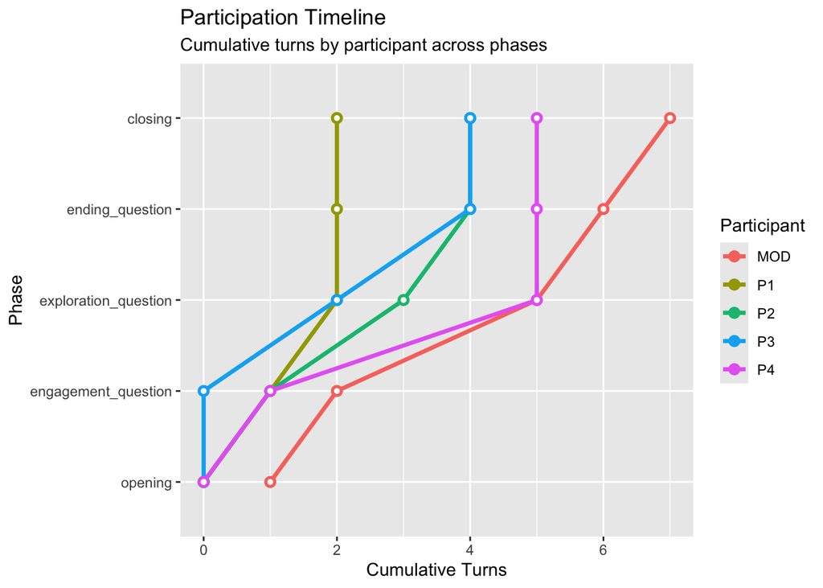

```r
plt_timeline <- tryCatch(fg$plot_participation_timeline(), error = function(e) NULL)
if (!is.null(plt_timeline)) print(plt_timeline) else cat("Participation timeline unavailable.\n")
```

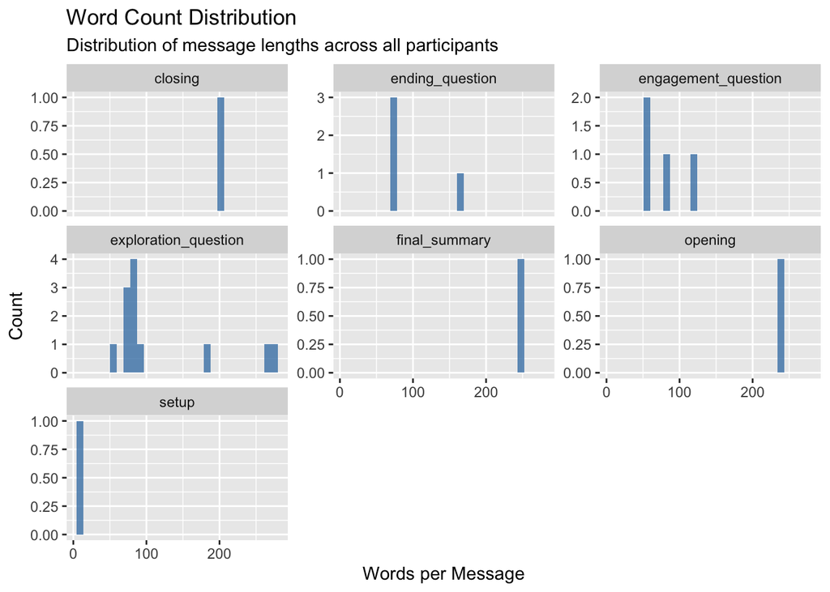

```r
plt_dist <- tryCatch(fg$plot_word_count_distribution(), error = function(e) NULL)
if (!is.null(plt_dist)) print(plt_dist) else cat("Word count distribution unavailable.\n")
```

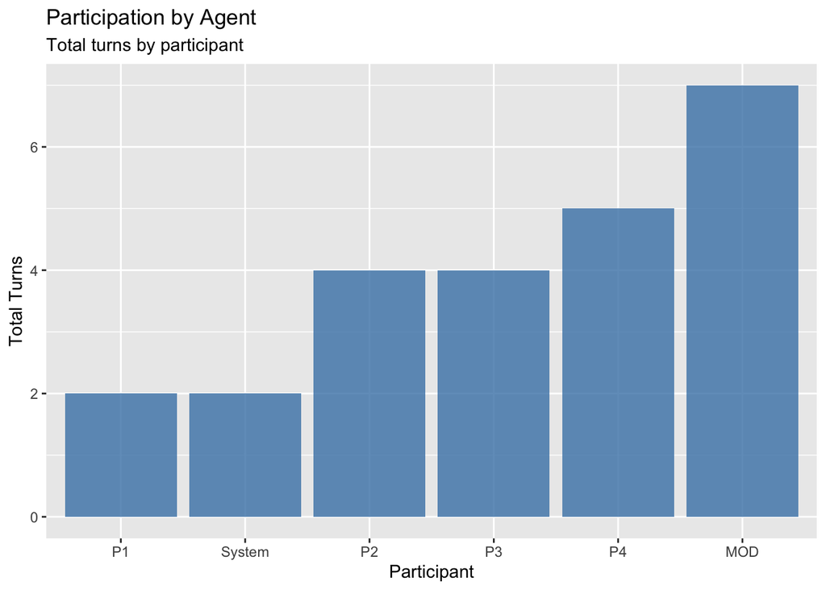

```r
plt_by_agent <- tryCatch(fg$plot_participation_by_agent(), error = function(e) NULL)
if (!is.null(plt_by_agent)) print(plt_by_agent) else cat("Participation by agent plot unavailable.\n")
```

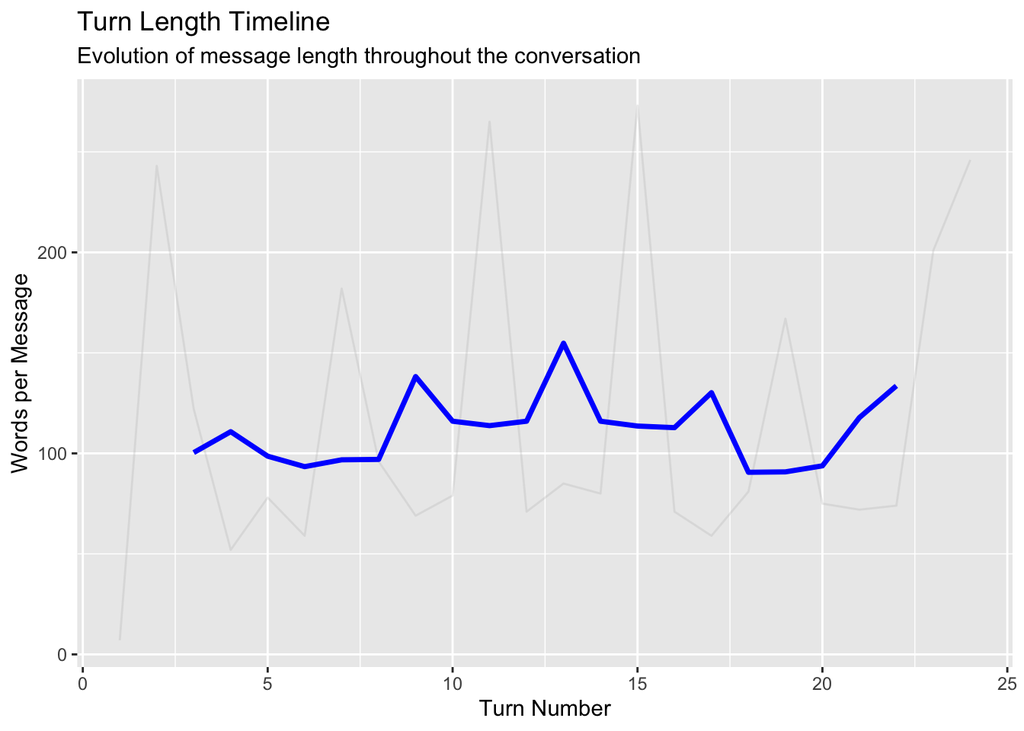

```r
plt_turn_len <- tryCatch(fg$plot_turn_length_timeline(), error = function(e) NULL)
if (!is.null(plt_turn_len)) print(plt_turn_len) else cat("Turn length timeline unavailable.\n")
```